# Jak oceniany jest rząd Beaty Szydło w rocznicę zaprzysiężenia?

W ostatnim tygodniu trafiłam na akrykuł prezentujący wyniki sondażu, mającego na celu ocenę rządu Beaty Szydło po roku od zaprzysiężenia (http://forsal.pl/galerie/992971,duze-zdjecie,1,pis-nieco-znieksztalcony-po-roku-rzadow.html)

Niestety, nie wszystkie dane na wykresach są czytelne i są sprzeczne z naszą intuicją ( “Trudno powiedzieć” znajduje się na końcu opinii ).Łatwo zauważyć, że podane liczby nie sumują się do 100%. Może to wynikać z zaokrągleń. Postanowiłam się skupić na dwóch typach wykresów, ktore pojawiły się w artykule.

Pierwszy z nich dotyczy oceny działań Beaty Szydło. Zwizualizowałam wyniki w podziale na wiek (analogicznie można postąpić z podziałem na miejsce zamieszkania). Dodałam również dane ogólne, aby stanowiły punkt odniesienia. Ponieważ opinia “Trudno powiedzieć” jest położona w środku, a jej wartości rozkładają się symetrycznie względem zera, dużo łatwiej jest zauważyć fakt, że we wszystkich grupach wiekowych Pani premier ma więcej przeciwników niż zwolenników. Poniżej zamieściłam tabelę z danymi.

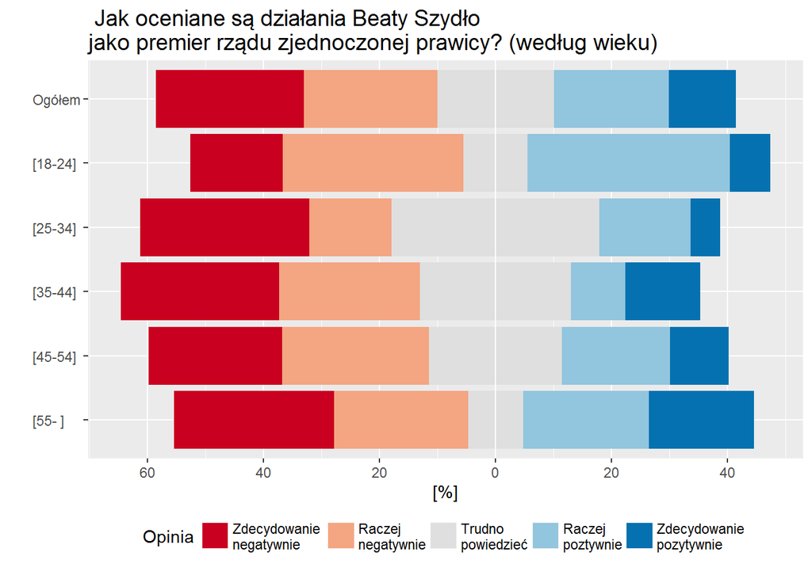

|  | Stan | Zdecydowanie negatywnie | Raczej negatywnie | Trudno powiedzieć | Raczej poztywnie | Zdecydowanie pozytywnie |
| --- | --- | --- | --- | --- | --- | --- |
| 1 | Ogółem | 25.50 | 23.00 | 20.10 | 19.80 | 11.60 |
| 2 | [18-24] | 15.90 | 31.20 | 11.00 | 34.90 | 7.00 |
| 3 | [25-34] | 29.20 | 14.20 | 35.80 | 15.70 | 5.10 |
| 4 | [35-44] | 27.30 | 24.30 | 26.10 | 9.30 | 13.00 |
| 5 | [45-54] | 23.10 | 25.30 | 22.90 | 18.60 | 10.10 |
| 6 | [55- ] | 27.60 | 23.10 | 9.50 | 21.70 | 18.10 |

### W jakim obszarze rząd radzi sobie:

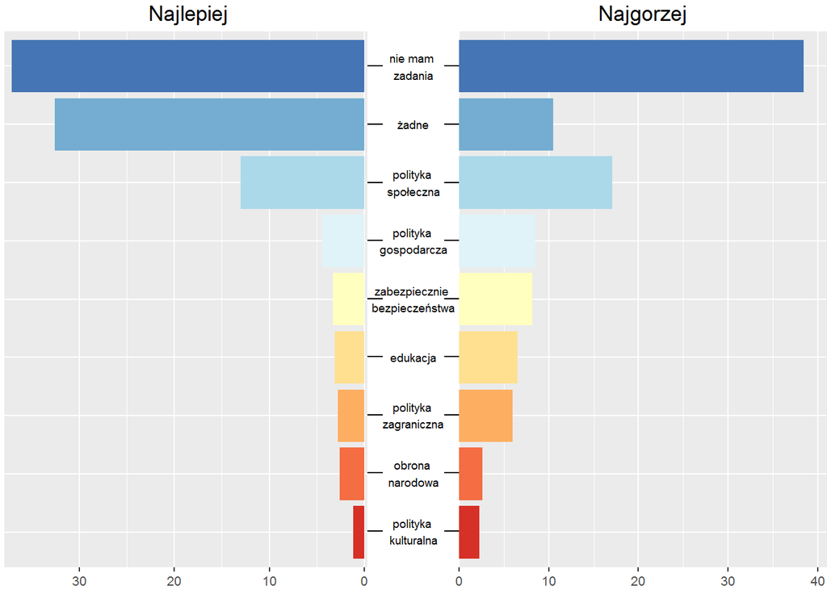

|  | Obszar | Najlepiej | Najgorzej |
| --- | --- | --- | --- |
| 1 | polityka społeczna | 13.00 | 17.10 |
| 2 | polityka gospodarcza | 4.50 | 8.50 |
| 3 | zabezpiecznie bezpieczeństwa | 3.30 | 8.20 |
| 4 | edukacja | 3.10 | 6.50 |
| 5 | polityka zagraniczna | 2.80 | 6.00 |
| 6 | obrona narodowa | 2.60 | 2.60 |
| 7 | polityka kulturalna | 1.20 | 2.30 |
| 8 | żadne | 32.60 | 10.50 |
| 9 | nie mam zadania | 37.10 | 38.40 |